# 03 – Explore the CausalCCC authors’ files (case study 2)

Fibroblasts, dendritic cells and T cells in atopic dermatitis skin, CellChat L-R pairs

Author

Minh Le, Jeanne Leclerc

Published

October 8, 2026

## Goal

This notebook does for case study 2 (Figure 3 and Supplementary Figure S1 of the paper) what notebook 01 did for case study 1. The files were downloaded by `scripts/case2/download_case2.sh` from the web server job `w0788tM1wzXGHLzNaKKa` (sources in `data/README.md`). We want to understand:

1. what the authors gave CausalCCC: the mosaic table, the variable list, the L-R pairs, the settings;
2. what CausalCCC returned;
3. whether the network supports what the paper says about Figure 3.

The new feature of this case study is that there are **three cell types**, and each one is both a sender and a receiver. The table also contains **metadata** (cell subtype and skin condition) as extra variables.

This notebook only **reads** files: nothing in `data/` is modified and nothing is written.

## Setup

The helper functions used in notebooks 01 and 02 (`find_repo_root()`, `neighbors_of()`, `graph_distance()`, …) are now in `scripts/helpers.R`, so that every notebook uses the same version. We load them with `source()`.

```r
library(tidyverse)

# find_repo_root() is needed before we know where helpers.R is, so this short loop is repeated here
root <- getwd()
while (!file.exists(file.path(root, "scripts", "helpers.R"))) {
  if (dirname(root) == root) stop("Repository root not found. Open the repository folder in Positron.")
  root <- dirname(root)
}
source(file.path(root, "scripts", "helpers.R"))

job_dir <- file.path(root, "data", "case2", "causalccc_server_w0788tM1wzXGHLzNaKKa")
if (!dir.exists(job_dir)) stop("Data not found: run scripts/case2/download_case2.sh first.")
```

## 1. Read the files

The same files as in case study 1. `guess_max = Inf` tells `read_tsv()` to look at every row before deciding the type of a column: the metadata columns are empty (`NA`) for thousands of rows before their first value, and without this option they would be read as logical columns.

```r
mosaic      <- read_tsv(file.path(job_dir, "input.tsv"), guess_max = Inf, show_col_types = FALSE)
state_order <- read_tsv(file.path(job_dir, "clean_state_order.tsv"), show_col_types = FALSE)
lr_pairs    <- read_tsv(file.path(job_dir, "clean_interact_edges.tsv"),
                        col_names = c("ligand", "receptor"), show_col_types = FALSE)
edges       <- read_tsv(file.path(job_dir, "edgesList.miic.summary.txt"), show_col_types = FALSE)
run_log     <- read_lines(file.path(job_dir, "whole_run.log"))

tibble(
  table   = c("mosaic", "state_order", "lr_pairs", "edges"),
  rows    = c(nrow(mosaic), nrow(state_order), nrow(lr_pairs), nrow(edges)),
  columns = c(ncol(mosaic), ncol(state_order), ncol(lr_pairs), ncol(edges))
)
```

```
# A tibble: 4 × 3
  table        rows columns
  <chr>       <int>   <int>
1 mosaic       7563     238
2 state_order   238       6
3 lr_pairs       43       2
4 edges        8458      17
```

The mosaic table is byte-for-byte identical to `data/case_study2/input.tsv`, the copy found online at the start of the project (same md5 checksum, checked when downloading).

## 2. How the server ran

```r
run_log |>
  str_subset("^Rscript") |>
  str_replace_all(" (--?[a-z])", "\n  \\1") |>
  cat()
```

```
Rscript /home/miic/miic_webserver/causalCCC_run_analysis.R
  -i /home/miic/server/server_outputs/w0788tM1wzXGHLzNaKKa/input.tsv
  -o /home/miic/server/server_outputs/w0788tM1wzXGHLzNaKKa
  -l orientation
  -e -1
  --complexity nml
  --conf_shuffle 100
  --conf_ratio 0.01
  --consistency no
  --orient_probab_ratio 0.01
  --n_threads 1
  --plots
  --orientation
  --test_MAR
  -s /home/miic/server/server_outputs/w0788tM1wzXGHLzNaKKa/clean_state_order.tsv
  --interact-edges /home/miic/server/server_outputs/w0788tM1wzXGHLzNaKKa/clean_interact_edges.tsv
  --miic_mode S
  --max_nodes 200
```

The settings are those of case study 1 (see notebook 02, section 2, for the meaning of each option), with one exception: `--n_threads 1` instead of 2. The time stamps of the log give the running time on the server:

```r
run_log |>
  str_subset("START miic|Search for conditional|confidence cut|Done!") |>
  str_trunc(110) |>
  cat(sep = "\n")
```

```
01/21/2025 01:12:30 PM  R : # -> START miic...
01/21/2025 02:00:26 PM  R : Search for conditional independence relations...
01/21/2025 04:06:41 PM  R : Compute confidence cut with permutations...72 edges cut.
01/21/2025 04:11:29 PM Done!
```

About three hours, most of it spent searching for conditional independences. The confidence filter removed 72 links.

## 3. The mosaic table

Each row is a cell of one of the three types. The metadata columns `labels_<type>` (cell subtype) are filled only for the cells of that type, so they tell us the type of each row. Then, as in notebook 01, the type of a column is the type of the rows where it has values.

```r
cell_types <- c("Fibroblasts", "T_cell", "DCs")

row_type <- case_when(!is.na(mosaic$labels_Fibroblasts) ~ "Fibroblasts",
                      !is.na(mosaic$labels_T_cell)      ~ "T_cell",
                      !is.na(mosaic$labels_DCs)         ~ "DCs")

col_type <- column_cell_type(mosaic, row_type)

tibble(cell_type = cell_types,
       cells     = map_int(cell_types, \(t) sum(row_type == t, na.rm = TRUE)),
       variables = map_int(cell_types, \(t) sum(col_type == t)))
```

```
# A tibble: 3 × 3
  cell_type   cells variables
  <chr>       <int>     <int>
1 Fibroblasts  4734        80
2 T_cell       2200        71
3 DCs           629        87
```

```r
# Every row has a type, and every column belongs to exactly one type?
c(rows_without_type = sum(is.na(row_type)), columns_shared = sum(!col_type %in% cell_types))
```

```
rows_without_type    columns_shared
                0                 0
```

Is the mosaic exactly made of three filled blocks? For each cell type we check that its rows are complete in its own columns and empty everywhere else.

```r
map(cell_types, \(t) {
  own_rows <- row_type == t
  own_cols <- col_type == t
  tibble(cell_type          = t,
         own_block_complete = !anyNA(mosaic[own_rows, own_cols]),
         elsewhere_empty    = all(is.na(mosaic[own_rows, !own_cols])))
}) |> list_rbind()
```

```
# A tibble: 3 × 3
  cell_type   own_block_complete elsewhere_empty
  <chr>       <lgl>              <lgl>
1 Fibroblasts TRUE               TRUE
2 T_cell      TRUE               TRUE
3 DCs         TRUE               TRUE
```

```r
rle(row_type)
```

```
Run Length Encoding
  lengths: int [1:3] 629 2200 4734
  values : chr [1:3] "DCs" "T_cell" "Fibroblasts"
```

Rows are grouped by cell type: dendritic cells, then T cells, then fibroblasts.

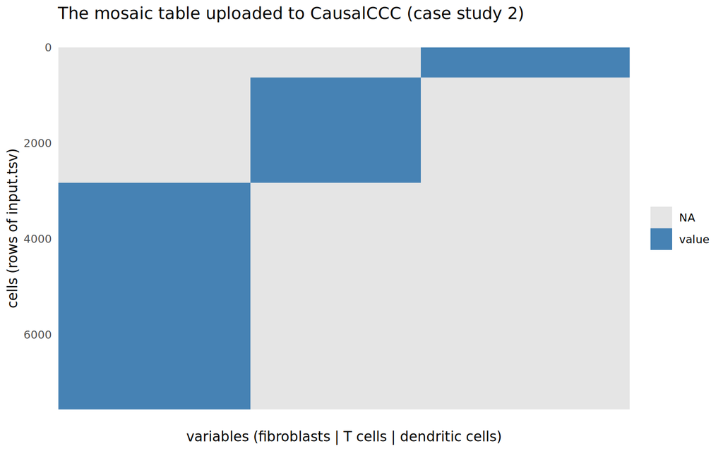

```r
col_order <- names(mosaic)[order(match(col_type, cell_types))]

mosaic |>
  mutate(across(everything(), \(v) !is.na(v)), cell = row_number()) |>
  pivot_longer(-cell, names_to = "variable", values_to = "has_value") |>
  mutate(variable = factor(variable, levels = col_order)) |>
  ggplot(aes(x = variable, y = cell, fill = has_value)) +
  geom_raster() +
  scale_y_reverse() +
  scale_fill_manual(values = c(`TRUE` = "steelblue", `FALSE` = "grey90"),
                    labels = c(`TRUE` = "value", `FALSE` = "NA")) +
  labs(x = "variables (fibroblasts | T cells | dendritic cells)", y = "cells (rows of input.tsv)", fill = NULL,
       title = "The mosaic table uploaded to CausalCCC (case study 2)") +
  theme_minimal() +
  theme(axis.text.x = element_blank(), panel.grid = element_blank())
```

### Variable names

In case study 1, a suffix (`_senders`, `_receivers`) was added only to genes measured on both sides. Here the rule looks similar but has gone wrong in places: some names carry the suffix twice. We split each name into its gene and its suffixes.

```r
names_tbl <- tibble(variable = names(mosaic), cell_type = col_type) |>
  mutate(suffixes = str_count(variable, paste0("_(", paste(cell_types, collapse = "|"), ")")),
         gene     = str_remove_all(variable, paste0("_(", paste(cell_types, collapse = "|"), ")")))

count(names_tbl, cell_type, suffixes)
```

```
# A tibble: 9 × 3
  cell_type   suffixes     n
  <chr>          <int> <int>
1 DCs                0    33
2 DCs                1    46
3 DCs                2     8
4 Fibroblasts        0    36
5 Fibroblasts        1    39
6 Fibroblasts        2     5
7 T_cell             0    26
8 T_cell             1    42
9 T_cell             2     3
```

```r
names_tbl |> filter(suffixes == 2) |> pull(variable)
```

```
 [1] "VIM_DCs_DCs"                     "LGALS1_DCs_DCs"
 [3] "SH3BGRL3_DCs_DCs"                "TMSB10_DCs_DCs"
 [5] "S100A4_DCs_DCs"                  "ACTB_DCs_DCs"
 [7] "S100A10_DCs_DCs"                 "ACTG1_DCs_DCs"
 [9] "B2M_T_cell_T_cell"               "VIM_T_cell_T_cell"
[11] "S100A6_T_cell_T_cell"            "S100A6_Fibroblasts_Fibroblasts"
[13] "TMSB4X_Fibroblasts_Fibroblasts"  "B2M_Fibroblasts_Fibroblasts"
[15] "VIM_Fibroblasts_Fibroblasts"     "S100A10_Fibroblasts_Fibroblasts"
```

Once the suffixes are removed, does a gene appear twice in the same cell type? If so, we compare the two columns on the cells of that type.

```r
duplicates <- names_tbl |>
  group_by(cell_type, gene) |>
  filter(n() == 2) |>
  summarise(copy_1 = first(variable), copy_2 = last(variable), .groups = "drop") |>
  mutate(identical = pmap_lgl(list(cell_type, copy_1, copy_2), \(t, a, b) {
    identical(mosaic[[a]][row_type == t], mosaic[[b]][row_type == t])
  }))

duplicates
```

```
# A tibble: 14 × 5
   cell_type   gene     copy_1                          copy_2         identical
   <chr>       <chr>    <chr>                           <chr>          <lgl>
 1 DCs         ANXA2    ANXA2_DCs                       ANXA2          TRUE
 2 DCs         LGALS1   LGALS1_DCs_DCs                  LGALS1_DCs     TRUE
 3 DCs         S100A10  S100A10_DCs_DCs                 S100A10_DCs    TRUE
 4 DCs         S100A4   S100A4_DCs_DCs                  S100A4_DCs     TRUE
 5 DCs         TMSB10   TMSB10_DCs_DCs                  TMSB10_DCs     TRUE
 6 Fibroblasts B2M      B2M_Fibroblasts_Fibroblasts     B2M_Fibroblas… TRUE
 7 Fibroblasts FTH1     FTH1                            FTH1_Fibrobla… TRUE
 8 Fibroblasts S100A10  S100A10_Fibroblasts_Fibroblasts S100A10_Fibro… TRUE
 9 Fibroblasts S100A6   S100A6_Fibroblasts_Fibroblasts  S100A6_Fibrob… TRUE
10 T_cell      ACTB     ACTB                            ACTB_T_cell    TRUE
11 T_cell      B2M      B2M_T_cell_T_cell               B2M_T_cell     TRUE
12 T_cell      H3F3B    H3F3B_T_cell                    H3F3B          TRUE
13 T_cell      S100A6   S100A6_T_cell_T_cell            S100A6_T_cell  TRUE
14 T_cell      SH3BGRL3 SH3BGRL3                        SH3BGRL3_T_ce… TRUE
```

```r
# Any gene present more than twice in a cell type?
names_tbl |> count(cell_type, gene) |> filter(n > 2)
```

```
# A tibble: 0 × 3
# ℹ 3 variables: cell_type <chr>, gene <chr>, n <int>
```

14 genes appear **twice in the same cell type, as two identical columns**. For example `S100A6_Fibroblasts` and `S100A6_Fibroblasts_Fibroblasts` hold the same numbers, and so do `ACTB` and `ACTB_T_cell`. One copy has one suffix more than the other. The table was probably assembled from several sender–receiver runs, in which the same gene got different names (notebook 05, section 10). Section 7 shows what this does to the network.

### Variable types and groups

```r
count(state_order, group)
```

```
# A tibble: 6 × 2
  group                 n
  <chr>             <int>
1 DCs genes            68
2 Fibroblasts genes    64
3 T_cell genes         56
4 ligands              19
5 metadata              6
6 receptors            25
```

```r
setequal(names(mosaic), state_order$var_names)
```

```
[1] TRUE
```

```r
state_order |> filter(var_type == 0) |> select(var_names, levels_increasing_order)
```

```
# A tibble: 6 × 2
  var_names             levels_increasing_order
  <chr>                 <chr>
1 labels_Fibroblasts    APOE+ FIB,FBN1+ FIB,COL11A1+ FIB,Inflam. FIB
2 condition_Fibroblasts NL,LS
3 labels_T_cell         TC,Inflam. TC,CD40LG+ TC,NKT
4 condition_T_cell      NL,LS
5 labels_DCs            cDC1,cDC2,LC,Inflam. DC
6 condition_DCs         NL,LS
```

The six discrete variables are the metadata: the cell subtype (`labels_*`, four subtypes per cell type, from the CellChat annotation) and the skin condition (`condition_*`: `LS` lesional or `NL` non-lesional skin of atopic dermatitis patients). Every gene is continuous.

```r
mosaic |>
  mutate(cell_type = row_type,
         subtype   = coalesce(labels_Fibroblasts, labels_T_cell, labels_DCs),
         condition = coalesce(condition_Fibroblasts, condition_T_cell, condition_DCs)) |>
  count(cell_type, condition) |>
  pivot_wider(names_from = condition, values_from = n)
```

```
# A tibble: 3 × 3
  cell_type      LS    NL
  <chr>       <int> <int>
1 DCs           563    66
2 Fibroblasts  2706  2028
3 T_cell       1742   458
```

Most dendritic cells and T cells come from lesional skin, while fibroblasts are more balanced.

### Raw counts?

```r
gene_cols <- state_order$var_names[state_order$var_type == 1]
values    <- unlist(mosaic[gene_cols], use.names = FALSE)
values    <- values[!is.na(values)]

tibble(minimum = min(values), maximum = max(values),
       all_integers = all(values == round(values)), fraction_zero = mean(values == 0))
```

```
# A tibble: 1 × 4
  minimum maximum all_integers fraction_zero
    <dbl>   <dbl> <lgl>                <dbl>
1       0    1080 TRUE                 0.409
```

## 4. The ligand–receptor pairs

The L-R pairs come from the CellChat analysis of this dataset (Jin *et al.*, *Nat Commun* 2021). Each ligand and receptor name carries the cell type that expresses it, so we can read off the direction of each pair.

```r
lr_pairs <- lr_pairs |>
  mutate(sender   = col_type[ligand],
         receiver = col_type[receptor])

count(lr_pairs, sender, receiver)
```

```
# A tibble: 6 × 3
  sender      receiver        n
  <chr>       <chr>       <int>
1 DCs         Fibroblasts     6
2 DCs         T_cell          7
3 Fibroblasts DCs            11
4 Fibroblasts T_cell          5
5 T_cell      DCs             9
6 T_cell      Fibroblasts     5
```

```r
# Every ligand declared a ligand, every receptor a receptor?
lr_pairs |>
  summarise(all_ligands_ok   = all(ligand %in% state_order$var_names[state_order$group == "ligands"]),
            all_receptors_ok = all(receptor %in% state_order$var_names[state_order$group == "receptors"]))
```

```
# A tibble: 1 × 2
  all_ligands_ok all_receptors_ok
  <lgl>          <lgl>
1 TRUE           TRUE
```

```r
lr_pairs |> filter(str_detect(ligand, "CXCL12"))
```

```
# A tibble: 2 × 4
  ligand             receptor     sender      receiver
  <chr>              <chr>        <chr>       <chr>
1 CXCL12_Fibroblasts CXCR4_T_cell Fibroblasts T_cell
2 CXCL12_Fibroblasts CXCR4_DCs    Fibroblasts DCs
```

The pairs cover all six directions between two different cell types; there is no autocrine pair (ligand and receptor in the same cell type). The pairs of Figure 3 (CXCL12 from fibroblasts to CXCR4 on dendritic cells and on T cells) are there.

How often is each ligand and receptor detected in its own cell type?

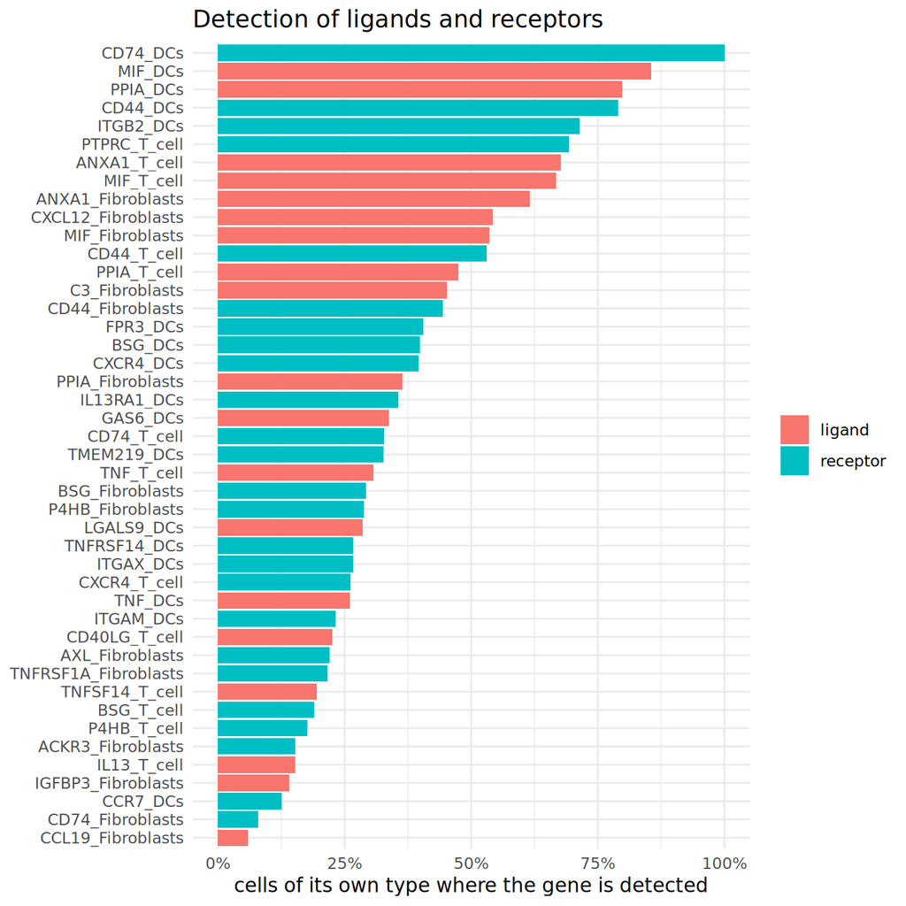

```r
lr_genes <- unique(c(lr_pairs$ligand, lr_pairs$receptor))

lr_expression <- mosaic[lr_genes] |>
  pivot_longer(everything(), names_to = "variable", values_to = "count") |>
  filter(!is.na(count)) |>
  group_by(variable) |>
  summarise(fraction_detected = mean(count > 0)) |>
  mutate(role = if_else(variable %in% lr_pairs$ligand, "ligand", "receptor"))

ggplot(lr_expression, aes(x = fraction_detected, y = reorder(variable, fraction_detected), fill = role)) +
  geom_col() +
  scale_x_continuous(labels = scales::percent, limits = c(0, 1)) +
  labs(x = "cells of its own type where the gene is detected", y = NULL, fill = NULL,
       title = "Detection of ligands and receptors") +
  theme_minimal()
```

```r
lr_expression |> filter(fraction_detected < 0.1) |> arrange(fraction_detected)
```

```
# A tibble: 2 × 3
  variable          fraction_detected role
  <chr>                         <dbl> <chr>
1 CCL19_Fibroblasts            0.0598 ligand
2 CD74_Fibroblasts             0.0792 receptor
```

## 5. The published network

We sort the retained links into categories using the cell type of each variable.

```r
count(edges, type)
```

```
# A tibble: 2 × 2
  type      n
  <chr> <int>
1 N      7743
2 P       715
```

```r
network <- edges |>
  filter(type == "P") |>
  mutate(type_x   = col_type[x],
         type_y   = col_type[y],
         category = if_else(type_x == type_y, paste("within", type_x), "ligand-receptor"))

count(network, category)
```

```
# A tibble: 4 × 2
  category               n
  <chr>              <int>
1 ligand-receptor       43
2 within DCs           225
3 within Fibroblasts   247
4 within T_cell        200
```

```r
# Number of cells used to learn each kind of link
count(network, category, cells_used = Nxy_ai)
```

```
# A tibble: 4 × 3
  category           cells_used     n
  <chr>                   <dbl> <int>
1 ligand-receptor            NA    43
2 within DCs                629   225
3 within Fibroblasts       4734   247
4 within T_cell            2200   200
```

Links within a cell type are learnt from the cells of that type only; the 43 L-R links are given, not learnt (`Nxy_ai` is `NA`).

**What MIIC reports for each link.** Three levels of evidence, from weakest to strongest, should not be confused:

| Level | Column | Meaning |
| --- | --- | --- |
| **Link present** | `type = P` | the two genes are dependent, even after conditioning on the other genes |
| **Oriented** | `infOrt = 2` or `-2` | MIIC found a likely direction (x → y or y → x) |
| **Genuine causation** | `is_causal = Y` | MIIC considers the edge a genuine cause–effect relation; the paper draws it with a green arrowhead |

Two other values of `infOrt`: `1` = not oriented, `6` = bidirected (a possible sign of a hidden common cause). A link can be oriented without being a genuine causation: this is the case of CXCL12 → CFD below. Most links are not oriented, and only a minority are genuine causations.

```r
network |>
  mutate(orientation = case_when(infOrt ==  1 ~ "not oriented",
                                 infOrt %in% c(2, -2) ~ "oriented",
                                 infOrt ==  6 ~ "bidirected")) |>
  count(category, orientation) |>
  pivot_wider(names_from = orientation, values_from = n, values_fill = 0)
```

```
# A tibble: 4 × 4
  category           oriented bidirected `not oriented`
  <chr>                 <int>      <int>          <int>
1 ligand-receptor          43          0              0
2 within DCs               48          5            172
3 within Fibroblasts       82         33            132
4 within T_cell            58          6            136
```

```r
count(network, is_causal)
```

```
# A tibble: 2 × 2
  is_causal     n
  <chr>     <int>
1 N           666
2 Y            49
```

**Hubs.**

```r
bind_rows(select(network, gene = x), select(network, gene = y)) |>
  count(gene, name = "links", sort = TRUE) |>
  head(10)
```

```
# A tibble: 10 × 2
   gene                           links
   <chr>                          <int>
 1 S100A6_Fibroblasts                24
 2 S100A6_Fibroblasts_Fibroblasts    24
 3 TMSB4X_T_cell                     20
 4 labels_Fibroblasts                20
 5 B2M_Fibroblasts                   17
 6 B2M_Fibroblasts_Fibroblasts       17
 7 HLA-DRA_DCs                       17
 8 VIM_DCs_DCs                       17
 9 ACTB                              16
10 ACTB_T_cell                       16
```

**The metadata variables** are part of the network. Their neighbours show which genes differ between subtypes or between lesional and non-lesional skin.

```r
metadata_vars <- state_order$var_names[state_order$group == "metadata"]

map(metadata_vars, \(m) neighbors_of(m, network)) |>
  list_rbind() |>
  group_by(node) |>
  summarise(links = n(), neighbors = paste(head(neighbor, 8), collapse = ", "))
```

```
# A tibble: 6 × 3
  node                  links neighbors
  <chr>                 <int> <chr>
1 condition_DCs             2 HLA-DQA2, EIF2AK4
2 condition_Fibroblasts     4 NNMT, IL32_Fibroblasts, COL6A5, C3_Fibroblasts
3 condition_T_cell          2 TMSB4X_T_cell, TNFRSF18
4 labels_DCs               10 FCER1G, IRF8, TXN, CCL22, LIPA, CCR7_DCs, FPR3_DC…
5 labels_Fibroblasts       20 MFAP5, COL1A1, COL6A5, APCDD1, TNC, APOE, IL32_Fi…
6 labels_T_cell            13 FOS, DUSP1_T_cell, DNAJB1, GADD45B, CD69, NR4A2, …
```

## 6. Does the network support the paper’s description of Figure 3?

Figure 3C shows the “second-degree neighbourhood” of the two CXCL12–CXCR4 links: the genes at most two links away from CXCL12 in fibroblasts and from CXCR4 in dendritic cells and in T cells. The text names specific genes in that neighbourhood. We look for them in the network **within each cell type**, that is, without the L-R links, which would otherwise connect everything through the receptors.

```r
intracellular <- network |> filter(category != "ligand-receptor")
```

**Statement 1.** CXCL12, secreted by fibroblasts, is linked to CXCR4 on dendritic cells and on T cells.

```r
network |>
  filter(str_detect(x, "^CXCL12") | str_detect(y, "^CXCL12")) |>
  filter(category == "ligand-receptor") |>
  select(x, y, infOrt, proba)
```

```
# A tibble: 2 × 4
  x                  y            infOrt proba
  <chr>              <chr>         <dbl> <chr>
1 CXCL12_Fibroblasts CXCR4_DCs         2 0.5;1
2 CXCL12_Fibroblasts CXCR4_T_cell      2 0.5;1
```

**Statement 2.** Upstream of CXCL12 in fibroblasts: the fibroblast marker DCN and the adipose-related genes APOD and CFD.

```r
neighbors_of("CXCL12_Fibroblasts", intracellular)
```

```
# A tibble: 5 × 5
  node               neighbor       infOrt is_causal direction
  <chr>              <chr>           <dbl> <chr>     <chr>
1 CXCL12_Fibroblasts CXCL14              1 N         none
2 CXCL12_Fibroblasts APOE                1 N         none
3 CXCL12_Fibroblasts CFH                 1 N         none
4 CXCL12_Fibroblasts CFD                -2 N         out
5 CXCL12_Fibroblasts C3_Fibroblasts     -2 N         out
```

```r
distance_cxcl12 <- graph_distance(intracellular, "CXCL12_Fibroblasts")
tibble(gene = c("DCN", "APOD", "CFD"), distance_from_CXCL12 = distance_cxcl12[gene])
```

```
# A tibble: 3 × 2
  gene  distance_from_CXCL12
  <chr>                <dbl>
1 DCN                      2
2 APOD                     2
3 CFD                      1
```

**Statement 3.** Downstream of CXCR4 in dendritic cells: GPR183 (migration), NR4A3 and VIM. In the table VIM of dendritic cells is called `VIM_DCs_DCs` (double suffix, section 3).

```r
neighbors_of("CXCR4_DCs", intracellular)
```

```
# A tibble: 3 × 5
  node      neighbor infOrt is_causal direction
  <chr>     <chr>     <dbl> <chr>     <chr>
1 CXCR4_DCs RGS1          1 N         none
2 CXCR4_DCs NR4A3         1 N         none
3 CXCR4_DCs UBC           1 N         none
```

```r
distance_cxcr4_dc <- graph_distance(intracellular, "CXCR4_DCs")
tibble(gene = c("GPR183", "NR4A3", "VIM_DCs_DCs"), distance_from_CXCR4 = distance_cxcr4_dc[gene])
```

```
# A tibble: 3 × 2
  gene        distance_from_CXCR4
  <chr>                     <dbl>
1 GPR183                        2
2 NR4A3                         1
3 VIM_DCs_DCs                   2
```

**Statement 4.** Downstream of CXCR4 in T cells: the AP-1 genes FOS and JUNB.

```r
neighbors_of("CXCR4_T_cell", intracellular)
```

```
# A tibble: 2 × 5
  node         neighbor infOrt is_causal direction
  <chr>        <chr>     <dbl> <chr>     <chr>
1 CXCR4_T_cell ZFP36         1 N         none
2 CXCR4_T_cell JUNB          1 N         none
```

```r
distance_cxcr4_t <- graph_distance(intracellular, "CXCR4_T_cell")
tibble(gene = c("FOS", "JUNB"), distance_from_CXCR4 = distance_cxcr4_t[gene])
```

```
# A tibble: 2 × 2
  gene  distance_from_CXCR4
  <chr>               <dbl>
1 FOS                     2
2 JUNB                    1
```

**The whole second-degree neighbourhood** (to compare by eye with Figure 3C):

```r
second_degree <- function(from) {
  d <- graph_distance(intracellular, from)
  d <- d[d <= 2]
  tibble(centre = from, gene = names(d), distance = d)
}

map(c("CXCL12_Fibroblasts", "CXCR4_DCs", "CXCR4_T_cell"), second_degree) |>
  list_rbind() |>
  filter(distance > 0) |>
  group_by(centre, distance) |>
  summarise(genes = paste(sort(gene), collapse = ", "), .groups = "drop")
```

```
# A tibble: 6 × 3
  centre             distance genes
  <chr>                 <dbl> <chr>
1 CXCL12_Fibroblasts        1 APOE, C3_Fibroblasts, CFD, CFH, CXCL14
2 CXCL12_Fibroblasts        2 APOD, C1R, CCL19_Fibroblasts, condition_Fibroblas…
3 CXCR4_DCs                 1 NR4A3, RGS1, UBC
4 CXCR4_DCs                 2 BSG_DCs, DUSP1_DCs, FTH1_DCs, GPR183, HLA-C_DCs, …
5 CXCR4_T_cell              1 JUNB, ZFP36
6 CXCR4_T_cell              2 BTG2, CD69, DNAJB1, DUSP2, FOS, GADD45B, H3F3B, H…
```

**Figure 3B** shows CXCL12 and CXCR4 expression in lesional skin. We draw the equivalent from the raw counts of the mosaic (on a `log1p` scale, i.e. log(1 + count)), separating lesional and non-lesional cells.

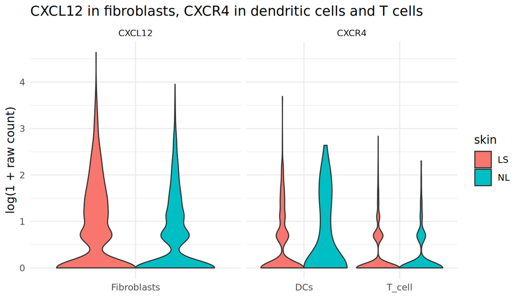

Figure 1

```r
tibble(cell_type = row_type,
       condition = coalesce(mosaic$condition_Fibroblasts, mosaic$condition_T_cell, mosaic$condition_DCs),
       CXCL12    = mosaic$CXCL12_Fibroblasts,
       CXCR4     = coalesce(mosaic$CXCR4_DCs, mosaic$CXCR4_T_cell)) |>
  pivot_longer(c(CXCL12, CXCR4), names_to = "gene", values_to = "count") |>
  filter(!is.na(count)) |>
  ggplot(aes(x = cell_type, y = log1p(count), fill = condition)) +
  geom_violin(scale = "width") +
  facet_wrap(~gene, scales = "free_x") +
  labs(x = NULL, y = "log(1 + raw count)", fill = "skin",
       title = "CXCL12 in fibroblasts, CXCR4 in dendritic cells and T cells") +
  theme_minimal()
```

## 7. What do the duplicated columns do to the network?

Two identical columns carry the same information, so MIIC finds the strongest possible link between them.

```r
duplicate_links <- link_name(duplicates$copy_1, duplicates$copy_2)

# Are the two copies of each duplicated gene linked to each other?
edges |>
  filter(link_name(x, y) %in% duplicate_links) |>
  count(type)
```

```
# A tibble: 1 × 2
  type      n
  <chr> <int>
1 P        14
```

```r
network |>
  filter(link_name(x, y) %in% duplicate_links) |>
  select(x, y, info_shifted, partial_correlation)
```

```
# A tibble: 14 × 4
   x                   y                        info_shifted partial_correlation
   <chr>               <chr>                           <dbl>               <dbl>
 1 S100A6_Fibroblasts  S100A6_Fibroblasts_Fibr…       11579.                   1
 2 S100A10_Fibroblasts S100A10_Fibroblasts_Fib…       10534.                   1
 3 FTH1                FTH1_Fibroblasts                9595.                   1
 4 B2M_Fibroblasts     B2M_Fibroblasts_Fibrobl…        8893.                   1
 5 B2M_T_cell          B2M_T_cell_T_cell               5766.                   1
 6 S100A6_T_cell       S100A6_T_cell_T_cell            5497.                   1
 7 ACTB                ACTB_T_cell                     4735.                   1
 8 SH3BGRL3            SH3BGRL3_T_cell                 4519.                   1
 9 H3F3B               H3F3B_T_cell                    4288.                   1
10 TMSB10_DCs          TMSB10_DCs_DCs                  1467.                   1
11 LGALS1_DCs          LGALS1_DCs_DCs                  1458.                   1
12 S100A10_DCs         S100A10_DCs_DCs                 1452.                   1
13 ANXA2               ANXA2_DCs                       1434.                   1
14 S100A4_DCs          S100A4_DCs_DCs                  1408.                   1
```

```r
# Rank of the strongest links among gene-gene links
network |>
  filter(category != "ligand-receptor") |>
  arrange(desc(info_shifted)) |>
  select(x, y, info_shifted) |>
  head(8)
```

```
# A tibble: 8 × 3
  x                   y                               info_shifted
  <chr>               <chr>                                  <dbl>
1 S100A6_Fibroblasts  S100A6_Fibroblasts_Fibroblasts        11579.
2 S100A10_Fibroblasts S100A10_Fibroblasts_Fibroblasts       10534.
3 FTH1                FTH1_Fibroblasts                       9595.
4 B2M_Fibroblasts     B2M_Fibroblasts_Fibroblasts            8893.
5 B2M_T_cell          B2M_T_cell_T_cell                      5766.
6 S100A6_T_cell       S100A6_T_cell_T_cell                   5497.
7 ACTB                ACTB_T_cell                            4735.
8 SH3BGRL3            SH3BGRL3_T_cell                        4519.
```

The 14 links between copies are the 14 strongest gene–gene links of their cell types, with a partial correlation of exactly 1. Since the L-R links are given the strength of the strongest link of the network, a duplicate also sets the strength of every L-R link.

Do the two copies of a gene have the same neighbours (apart from each other)?

```r
intracellular_all <- network |> filter(category != "ligand-receptor")

duplicates |>
  mutate(neighbours = map2(copy_1, copy_2, \(a, b) {
    n_a <- setdiff(neighbors_of(a, intracellular_all)$neighbor, b)
    n_b <- setdiff(neighbors_of(b, intracellular_all)$neighbor, a)
    tibble(links_copy_1 = length(n_a), links_copy_2 = length(n_b), shared = length(intersect(n_a, n_b)))
  })) |>
  unnest(neighbours) |>
  select(cell_type, gene, links_copy_1, links_copy_2, shared)
```

```
# A tibble: 14 × 5
   cell_type   gene     links_copy_1 links_copy_2 shared
   <chr>       <chr>           <int>        <int>  <int>
 1 DCs         ANXA2               4            4      4
 2 DCs         LGALS1             12           12     12
 3 DCs         S100A10             5            5      5
 4 DCs         S100A4              6            6      6
 5 DCs         TMSB10             12           12     12
 6 Fibroblasts B2M                16           16     16
 7 Fibroblasts FTH1               11           11     11
 8 Fibroblasts S100A10             9            9      9
 9 Fibroblasts S100A6             23           23     23
10 T_cell      ACTB               15           15     15
11 T_cell      B2M                14           14     14
12 T_cell      H3F3B               5            5      5
13 T_cell      S100A6              7            7      7
14 T_cell      SH3BGRL3            5            5      5
```

Each duplicated gene thus enters the network twice, with each neighbour linked to both copies: its links are counted twice, which inflates its importance as a hub. The two copies also count as two variables when MIIC looks for separating sets and for orientations. For the Figure 3 claims this matters little (none of the genes named in the text is duplicated), but it should be fixed when we rebuild the input.

## What we learned

**Inputs.** The mosaic has 7,563 cells (4,734 fibroblasts, 2,200 T cells, 629 dendritic cells): the full CellChat `data_humanSkin` dataset, i.e. all cells of these three types from He *et al.* 2020. It has 238 variables: 232 genes (raw integer counts) and 6 discrete metadata (cell subtype and lesional/non-lesional skin, for each cell type). The 43 CellChat L-R pairs connect the three cell types in both directions.

**Network.** 715 links were kept out of 8,458 examined. The server needed about three hours, single-threaded.

**Paper’s statements (Figure 3C).** All supported, within the second-degree neighbourhood that the figure draws:

- CXCL12 in fibroblasts is linked to CXCR4 in dendritic cells and in T cells (given L-R links).
- CFD is a direct neighbour of CXCL12; DCN and APOD are two links away. Note that MIIC orients the link CXCL12 → CFD (not a genuine causation): CFD is on the fibroblast side, but the network does not put it upstream of CXCL12.
- NR4A3 is a direct neighbour of CXCR4 in dendritic cells; GPR183 and VIM are two links away.
- JUNB is a direct neighbour of CXCR4 in T cells; FOS is two links away.

The paper speaks of “upstream” and “downstream” genes. None of the links around CXCR4 is oriented, and the only oriented links of CXCL12 point away from it, so these words describe the position relative to the L-R link (sender side, receiver side) rather than a causal direction found by MIIC.

**Points for the preprocessing assessment.**

- 14 genes appear twice in the same cell type as identical columns, under two names that differ by one suffix (`S100A6_Fibroblasts` / `S100A6_Fibroblasts_Fibroblasts`, `ACTB` / `ACTB_T_cell`, …). The link between two copies is the strongest of its cell type, and the gene’s links are counted twice (section 7).
- Two L-R genes are detected in fewer than 10 % of the cells of their type: CCL19 (6 % of fibroblasts) and CD74 in fibroblasts (8 %).
- Dendritic cells are few (629) and mostly from lesional skin: links within dendritic cells are learnt from fewer cells.